# Marine heatwaves around Denmark

Analysis performed Wed Apr 29 16:48:19 2020.

This webpage is updated daily.

## Status

Current Marine Heatwave status based on ocean temperature data for Mon 27 Apr 2020.

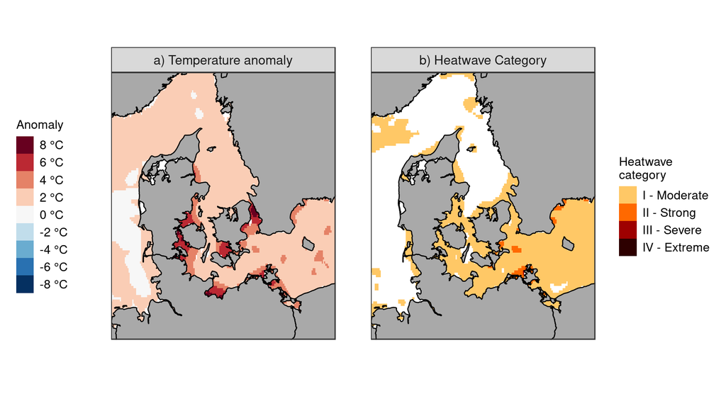

**Figure 1. Current status of ocean temperatures.** *The current status can be seen as a) the current observed sea-surface temperature (SST) anomaly (i.e. observed minus the long-term mean on a given day) and b) associated heatwave severity based on the Hobday marine heatwave scale (Hobday et al 2018).*

## Last 12 months

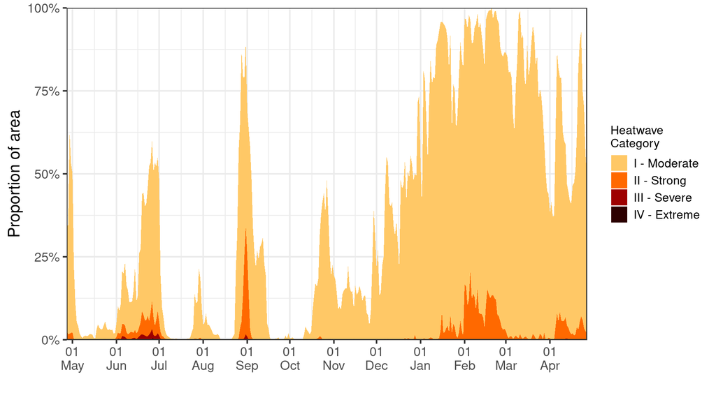

**Figure 2. Proportion of study area impacted by MHWs.** *The proportion of the study area in Figure 1 in a given Marine Heatwave category is plotted over the last 12 months. Categories are stacked on top of each other, so that the upper edge of a category corresponds to the proportion that is in that category or higher. Heatwave severity is classified following the Hobday marine heatwave scale (Hobday et al 2018).*

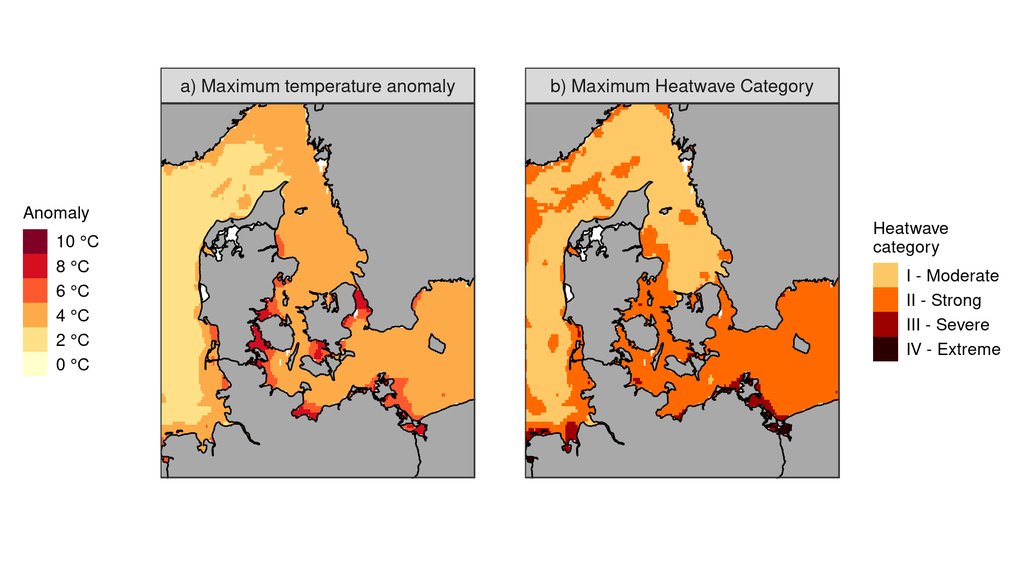

**Figure 3. Extreme temperatures over the last 12 months.** *The most extreme temperatures observed over the last 12 months can be seen as a) the maximum daily observed sea-surface temperature (SST) anomaly (i.e. observed minus the long-term mean on a given day) and b) the maximum heatwave severity based on the Hobday marine heatwave scale (Hobday et al 2018).*

## Selected Regions

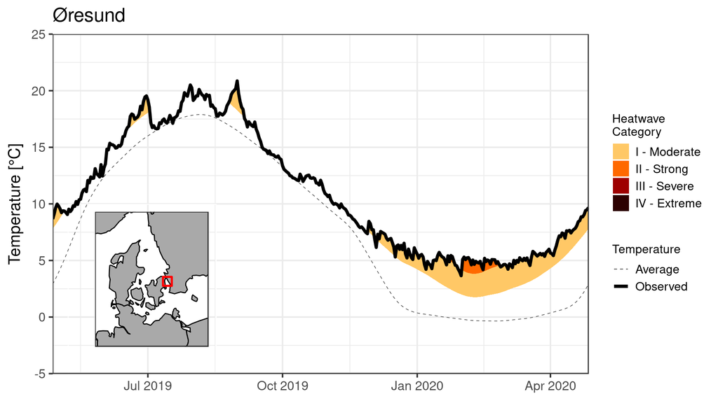

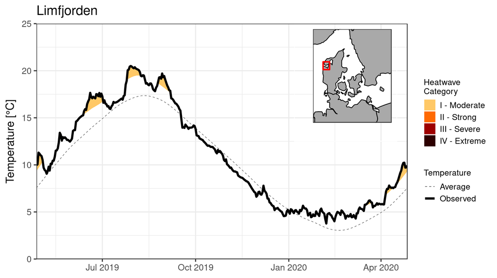

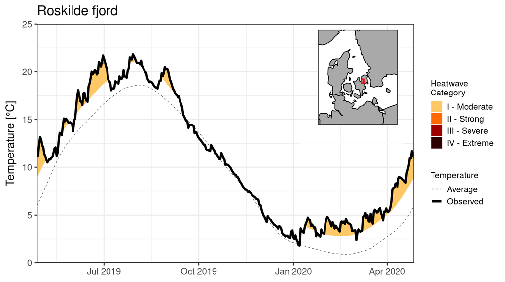

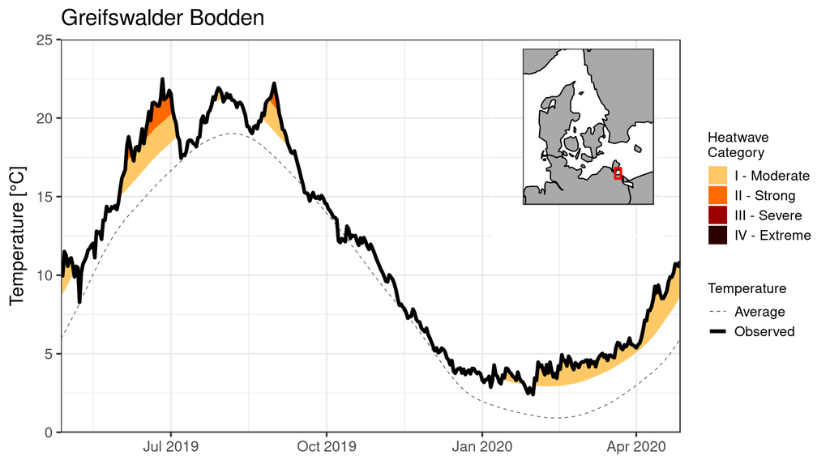

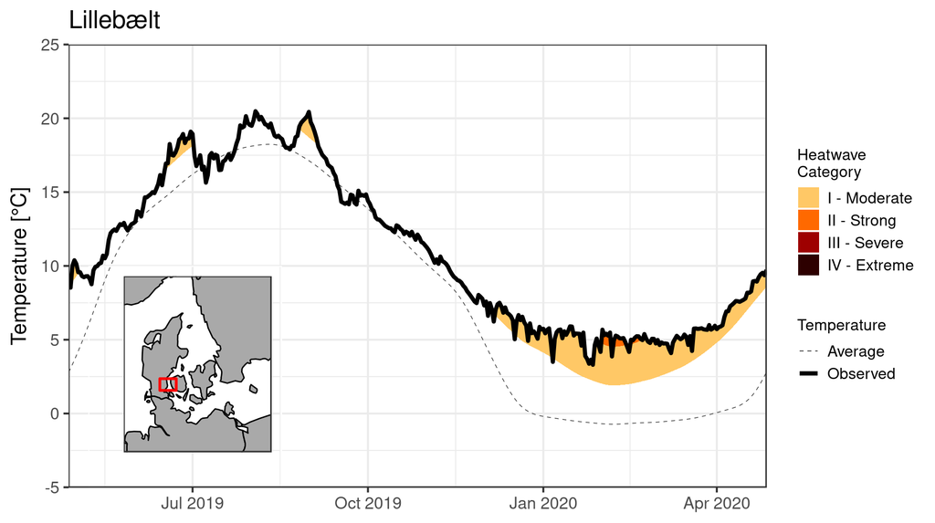

**Figure 4. Time series for selected regions.** *Time series plot showing the temporal evolution of temperature over the last twelve months and its relationship to Marine Heatwave categories on the Hobday marine heatwave scale (Hobday et al 2018).*

## Basis of Analysis

**Table 1. Overview of the basis for the analysis**

[output not shown]

## References

- Hobday, A., Oliver, E., Sen Gupta, A., Benthuysen, J., Burrows, M., Donat, M., … Smale, D. (2018). Categorizing and Naming Marine Heatwaves. Oceanography, 31(2), 477–486. https://doi.org/10.5670/oceanog.2018.205
- Hobday, A. J., Alexander, L. V., Perkins, S. E., Smale, D. A., Straub, S. C., Oliver, E. C. J., … Wernberg, T. (2016). A hierarchical approach to defining marine heatwaves. Progress in Oceanography, 141, 227–238. https://doi.org/10.1016/j.pocean.2015.12.014

## License Information

This work by Mark R. Payne is licensed under a Creative Commons Attribution-NonCommercial-ShareAlike 3.0 Unported License. For details, see http://creativecommons.org/licenses/by-nc-sa/3.0/deed.en_US Basically, this means that you are free to “share” and “remix” for non-commercial purposes as you see fit, so long as you “attribute” me for my contribution. Derivatives can be distributed under the same or similar license.

This work comes with ABSOLUTELY NO WARRANTY or support.

## Acknowledgements

The authors would like to thank the authors of the heatwaveR package for making these tools available.